# HW3

Anubhav Shankar

2022-11-29

Let’s generate a non-linear data-set on which Neural Networks outperforms Logistic Regression.

**Dataset Description**: The planar data is a **randomly generated non-linear dataset** which would need multiple decision boundaries to get an accurate classification or prediction.

```r
planar_dataset <- function(){ # A function makes it easier to modify the parameters, if required
set.seed(123) # To ensure reproducibility
m <- 800 # Total length of the data frame
N <- m/2 # Sample size
D <- 2 # Dimensions
X <- matrix(0, nrow = m, ncol = D) # matrix where each row is a single example
Y <- matrix(0, nrow = m, ncol = 1) # label vector (0 for red, 1 for blue)
a <- 5 # Max value of the flower spread
for(j in 0:1){ # For loop to generate a random sample
      ix <- seq((N*j)+1, N*(j+1)) # range for sequence generation
      t <- seq(j*3.12,(j+1)*3.12,length.out = N) + rnorm(N, sd = 0.2) # petal inclination
      r <- a*sin(4*t) + rnorm(N, sd = 0.2) # radius
      X[ix,1] <- r*sin(t) # fills the first column of the X matrix
      X[ix,2] <- r*cos(t) # fills the second column of the X matrix
      Y[ix,] <- j # will have value between 0 & 1
}
d <- as.data.frame(cbind(X, Y)) # Create a data-frame
names(d) <- c('X1','X2','Y') # Rename the columns accordingly
d
}
```

```r
df <- planar_dataset()
df <- df[sample(nrow(df)), ] # Shuffle dataset
head(df)
```

```
##            X1         X2 Y
## 740  2.053348 -3.3966571 1
## 730 -1.897771  1.4929127 1
## 648 -3.592936  0.8797975 1
## 342 -1.210739  4.1583541 0
## 123 -1.155820 -1.0033961 0
## 700 -1.307497  1.0938884 1
```

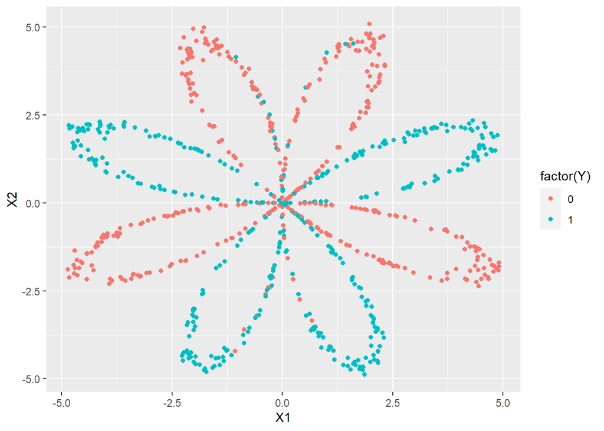

```r
ggplot(df, aes(x = X1, y = X2, color = factor(Y))) +
geom_point()
```

```r
set.seed(123) # For reproducibility
index <- sample(1:nrow(df), 0.8 * nrow(df), replace = FALSE) # Do a 80-20 train-test split
train <- df[index,]
test <- df[-index,]

glimpse(train) # Get a quick glance of the data-frame structure
```

```
## Rows: 640
## Columns: 3
## $ X1 <dbl> -1.158604778, 0.812910525, -3.371047466, -0.155050665, -1.816881952…
## $ X2 <dbl> 4.09778115, -0.73494525, -2.01363648, 1.67141934, 2.62977897, 1.559…
## $ Y  <dbl> 0, 0, 0, 0, 0, 1, 0, 0, 0, 1, 0, 0, 0, 0, 0, 0, 1, 1, 1, 1, 0, 0, 0…
```

```r
glimpse(test)
```

```
## Rows: 160
## Columns: 3
## $ X1 <dbl> 2.05334818, -3.59293564, 4.72474337, 3.73321458, 1.55710728, 4.7002…
## $ X2 <dbl> -3.396657065, 0.879797525, 1.532745099, -1.992538553, 4.651756167, …
## $ Y  <dbl> 1, 1, 1, 0, 0, 0, 0, 1, 0, 0, 1, 0, 0, 0, 1, 1, 1, 0, 0, 1, 0, 0, 0…
```

```r
logit_train <- glm(Y ~ ., data = train, family = "binomial")
summary(logit_train) # Logistic regression using training set
```

```
##
## Call:
## glm(formula = Y ~ ., family = "binomial", data = train)
##
## Deviance Residuals:
##     Min       1Q   Median       3Q      Max
## -1.6198  -1.2205   0.7633   1.1721   1.5631
##
## Coefficients:
##              Estimate Std. Error z value Pr(>|z|)
## (Intercept)  0.095684   0.082008   1.167    0.243
## X1           0.002088   0.032355   0.065    0.949
## X2          -0.214626   0.034320  -6.254 4.01e-10 ***
## ---
## Signif. codes:  0 '***' 0.001 '**' 0.01 '*' 0.05 '.' 0.1 ' ' 1
##
## (Dispersion parameter for binomial family taken to be 1)
##
##     Null deviance: 886.60  on 639  degrees of freedom
## Residual deviance: 844.39  on 637  degrees of freedom
## AIC: 850.39
##
## Number of Fisher Scoring iterations: 4
```

```r
logLik(logit_train) # Log likelihood of training set
```

```
## 'log Lik.' -422.1966 (df=3)
```

```r
with(logit_train, pchisq(null.deviance - deviance, df.null - df.residual, lower.tail = FALSE)) # p-value of the training dataset
```

```
## [1] 6.826302e-10
```

```r
pR2(logit_train)["McFadden"] # Logistic Regression equivalent of R-squared
```

```
## fitting null model for pseudo-r2
```

```
##   McFadden
## 0.04760882
```

```r
vif(logit_train) # Check for multicollinearity
```

```
##       X1       X2
## 1.000042 1.000042
```

```r
predictions_test <- predict(logit_train, test, type = "response")
predict_binary_test <- ifelse(predictions_test > 0.5, 1, 0)
cftable_test <- table(predict_binary_test, test$Y)
cftable_test
```

```
##
## predict_binary_test  0  1
##                   0 35 30
##                   1 55 40
```

```r
accuracy_test <- sum(diag(cftable_test))/sum(cftable_test)
accuracy_test
```

```
## [1] 0.46875
```

```r
sensitivity_test <- cftable_test[1]/(cftable_test[1] + cftable_test[2])
sensitivity_test
```

```
## [1] 0.3888889
```

```r
specificity_test <- cftable_test[4]/(cftable_test[3] + cftable_test[4])
specificity_test
```

```
## [1] 0.5714286
```

```r
ppv_test <- cftable_test[1]/(cftable_test[1] + cftable_test[3])
ppv_test
```

```
## [1] 0.5384615
```

```r
npv_test <- cftable_test[4]/(cftable_test[2] + cftable_test[4])
npv_test
```

```
## [1] 0.4210526
```

```r
error <- mean(predict_binary_test!=test$Y)
error
```

```
## [1] 0.53125
```

```r
accuracy <- 1-error
accuracy
```

```
## [1] 0.46875
```

```r
roc_test <- roc(test$Y,predictions_test)
```

```r
plot.roc(roc_test, col=par("fg"),plot=TRUE,print.auc = FALSE, legacy.axes = TRUE, asp =NA)
roc_test
```

```
##
## Call:
## roc.default(response = test$Y, predictor = predictions_test)
##
## Data: predictions_test in 90 controls (test$Y 0) > 70 cases (test$Y 1).
## Area under the curve: 0.4049
```

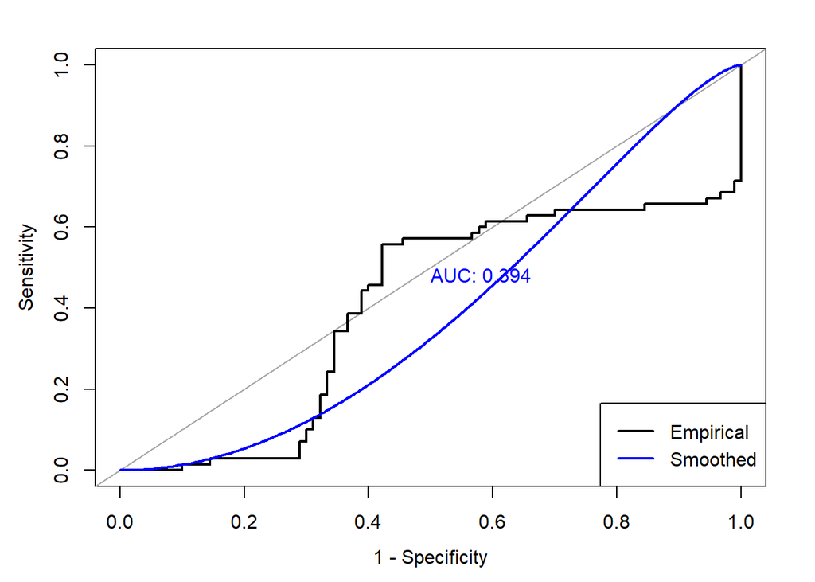

```r
plot.roc(smooth(roc_test), col="blue", add = TRUE,plot=TRUE,print.auc = TRUE, legacy.axes = TRUE, asp =NA)
legend("bottomright", legend=c("Empirical", "Smoothed"),
       col=c(par("fg"), "blue"), lwd=2)
```

From the above observations we can conclude that Logistic Regression (LR) is not an appropriate model for this data. This is primarily due to the fact that Logistic Regression by default creates only one decision boundary. However, the Planar dataset is intentionally in a non-linear space, owing to the utilization of Sine and Cosine functions, hence, LR will have a horrible performance under such circumstances as shown by the AUC plot above.

```r
seed <- 490
set.seed(seed)

planar_nn <- neuralnet(Y~., data = train, hidden = 5, rep = 100, stepmax = 10000) # Run a neural network
```

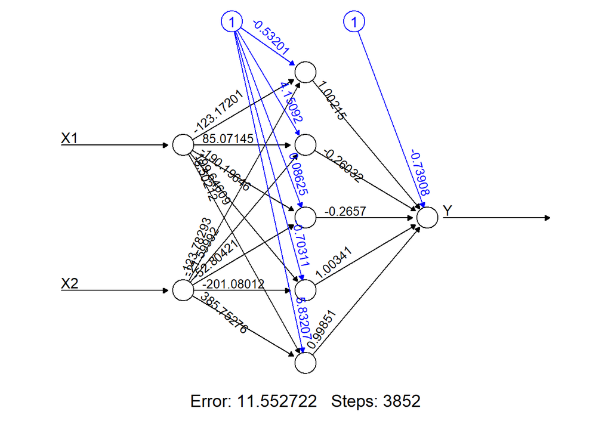

```r
plot(planar_nn, rep = 1) #Plot the NN structure with a single repetition
```

```r
predict <- compute(planar_nn, test[,c(1:2)]) # Predict the trained model on the test set

#head(predict$net.result) # View the converged results - OPTIONAL!
p <- predict$net.result #Store the predicted values

prediction <- ifelse(p>0.5,1,0) # Create the decision boundaries
pred_table <- table(prediction,test$Y) # Generate a confusion matrix
pred_table
```

```
##
## prediction  0  1
##          0 85  6
##          1  5 64
```

```r
error_nn <- 1-sum(diag(pred_table))/sum(pred_table) # Error of the NN
error_nn
```

```
## [1] 0.06875
```

```r
accuracy_nn <- 1-error_nn # Accuracy of the NN
accuracy_nn
```

```
## [1] 0.93125
```

**Datset Description**: The sinking of the Titanic is one of the most infamous shipwrecks in history.

On April 15, 1912, during her maiden voyage, the widely considered “unsinkable” RMS Titanic sank after colliding with an iceberg. Unfortunately, there weren’t enough lifeboats for everyone onboard, resulting in the death of 1502 out of 2224 passengers and crew.

While there was some element of luck involved in surviving, it seems some groups of people were more likely to survive than others.

In this competition, you’ll gain access to two similar datasets that include passenger information like name, age, gender, socio-economic class, etc. One dataset is titled “train.csv” and the other is titled “test.csv”.

Train.csv will contain the details of a subset of the passengers on board (891 to be exact) and importantly, will reveal whether they survived or not, also known as the “ground truth”.

The `test.csv` dataset contains similar information but does not disclose the “ground truth” for each passenger. It’s your job to predict these outcomes.

Using the patterns you find in the train.csv data, predict whether the other 418 passengers on board (found in test.csv) survived.

```r
train <- titanic_train # The Training Set
test <- titanic_test # The Testing Set
glimpse(train) # Analyze the metadata
```

```
## Rows: 891
## Columns: 12
## $ PassengerId <int> 1, 2, 3, 4, 5, 6, 7, 8, 9, 10, 11, 12, 13, 14, 15, 16, 17,…
## $ Survived    <int> 0, 1, 1, 1, 0, 0, 0, 0, 1, 1, 1, 1, 0, 0, 0, 1, 0, 1, 0, 1…
## $ Pclass      <int> 3, 1, 3, 1, 3, 3, 1, 3, 3, 2, 3, 1, 3, 3, 3, 2, 3, 2, 3, 3…
## $ Name        <chr> "Braund, Mr. Owen Harris", "Cumings, Mrs. John Bradley (Fl…
## $ Sex         <chr> "male", "female", "female", "female", "male", "male", "mal…
## $ Age         <dbl> 22, 38, 26, 35, 35, NA, 54, 2, 27, 14, 4, 58, 20, 39, 14, …
## $ SibSp       <int> 1, 1, 0, 1, 0, 0, 0, 3, 0, 1, 1, 0, 0, 1, 0, 0, 4, 0, 1, 0…
## $ Parch       <int> 0, 0, 0, 0, 0, 0, 0, 1, 2, 0, 1, 0, 0, 5, 0, 0, 1, 0, 0, 0…
## $ Ticket      <chr> "A/5 21171", "PC 17599", "STON/O2. 3101282", "113803", "37…
## $ Fare        <dbl> 7.2500, 71.2833, 7.9250, 53.1000, 8.0500, 8.4583, 51.8625,…
## $ Cabin       <chr> "", "C85", "", "C123", "", "", "E46", "", "", "", "G6", "C…
## $ Embarked    <chr> "S", "C", "S", "S", "S", "Q", "S", "S", "S", "C", "S", "S"…
```

```r
glimpse(test)
```

```
## Rows: 418
## Columns: 11
## $ PassengerId <int> 892, 893, 894, 895, 896, 897, 898, 899, 900, 901, 902, 903…
## $ Pclass      <int> 3, 3, 2, 3, 3, 3, 3, 2, 3, 3, 3, 1, 1, 2, 1, 2, 2, 3, 3, 3…
## $ Name        <chr> "Kelly, Mr. James", "Wilkes, Mrs. James (Ellen Needs)", "M…
## $ Sex         <chr> "male", "female", "male", "male", "female", "male", "femal…
## $ Age         <dbl> 34.5, 47.0, 62.0, 27.0, 22.0, 14.0, 30.0, 26.0, 18.0, 21.0…
## $ SibSp       <int> 0, 1, 0, 0, 1, 0, 0, 1, 0, 2, 0, 0, 1, 1, 1, 1, 0, 0, 1, 0…
## $ Parch       <int> 0, 0, 0, 0, 1, 0, 0, 1, 0, 0, 0, 0, 0, 0, 0, 0, 0, 0, 0, 0…
## $ Ticket      <chr> "330911", "363272", "240276", "315154", "3101298", "7538",…
## $ Fare        <dbl> 7.8292, 7.0000, 9.6875, 8.6625, 12.2875, 9.2250, 7.6292, 2…
## $ Cabin       <chr> "", "", "", "", "", "", "", "", "", "", "", "", "B45", "",…
## $ Embarked    <chr> "Q", "S", "Q", "S", "S", "S", "Q", "S", "C", "S", "S", "S"…
```

```r
colSums(is.na(train) | train == " ") # Check for NAs and blank values
```

```
## PassengerId    Survived      Pclass        Name         Sex         Age
##           0           0           0           0           0         177
##       SibSp       Parch      Ticket        Fare       Cabin    Embarked
##           0           0           0           0           0           0
```

```r
colSums(is.na(test) | test == " ")
```

```
## PassengerId      Pclass        Name         Sex         Age       SibSp
##           0           0           0           0          86           0
##       Parch      Ticket        Fare       Cabin    Embarked
##           0           0           1           0           0
```

```r
set.seed(444)

titanic_glm <- glm(Survived ~ Sex, data = train_copy, family = 'binomial')
summary(titanic_glm)
```

```
##
## Call:
## glm(formula = Survived ~ Sex, family = "binomial", data = train_copy)
##
## Deviance Residuals:
##     Min       1Q   Median       3Q      Max
## -1.6462  -0.6471  -0.6471   0.7725   1.8256
##
## Coefficients:
##             Estimate Std. Error z value Pr(>|z|)
## (Intercept)   1.0566     0.1290   8.191 2.58e-16 ***
## Sexmale      -2.5137     0.1672 -15.036  < 2e-16 ***
## ---
## Signif. codes:  0 '***' 0.001 '**' 0.01 '*' 0.05 '.' 0.1 ' ' 1
##
## (Dispersion parameter for binomial family taken to be 1)
##
##     Null deviance: 1186.7  on 890  degrees of freedom
## Residual deviance:  917.8  on 889  degrees of freedom
## AIC: 921.8
##
## Number of Fisher Scoring iterations: 4
```

```r
# Test for accuracy
predict_sex_survived <- predict(titanic_glm,newdata = test_copy,type = 'response')
# Since Survived can only be either 1 or 0, write if statement to round up of down the response
predict_sex_survived <- ifelse(predict_sex_survived>0.5,1,0)
error_1 <- mean(predict_sex_survived!=test_copy$Survived)
accuracy_1 <- 1-error_1
accuracy_1
```

```
## [1] 0.7559809
```

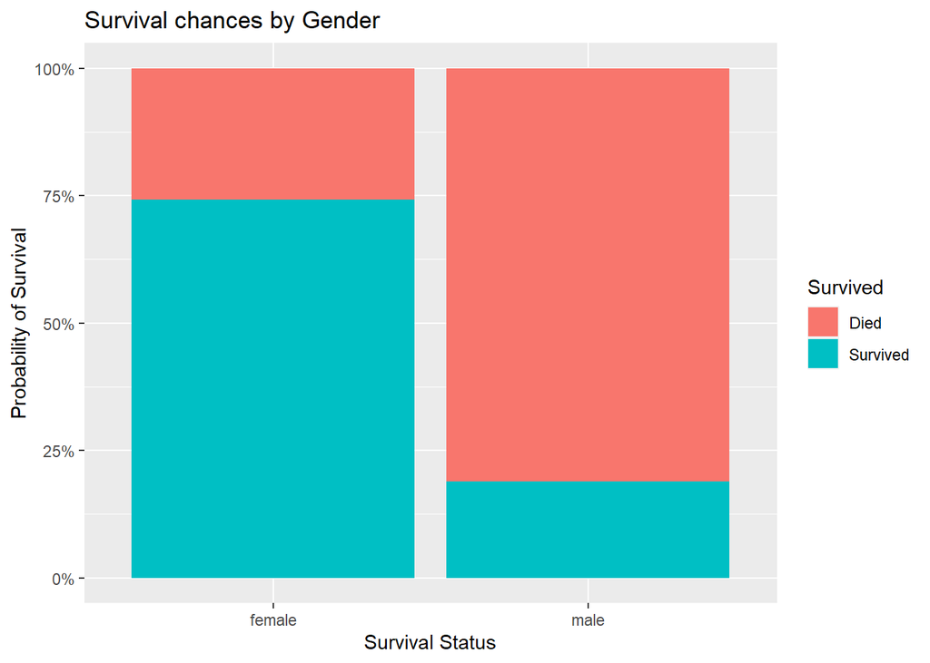

```r
prob_survival <- data.frame(prob_survival = titanic_glm$fitted.values,Survived = train_copy$Survived, Sex = train_copy$Sex)

ggplot(prob_survival, aes(fill = Survived, y = prob_survival, x = Sex)) +
  geom_bar(position = "fill", stat = "identity") +
  labs(x= "Survival Status", y = "Probability of Survival", title = "Survival chances by Gender") +
  scale_y_continuous(labels = scales::percent_format()) +
  scale_fill_discrete(labels = c("Died","Survived"))
```

```r
logistic_complete <- glm(Survived~., data = train_copy, family = "binomial")
summary(logistic_complete)
```

```
##
## Call:
## glm(formula = Survived ~ ., family = "binomial", data = train_copy)
##
## Deviance Residuals:
##     Min       1Q   Median       3Q      Max
## -2.6834  -0.6053  -0.4060   0.6202   2.4785
##
## Coefficients:
##               Estimate Std. Error z value Pr(>|z|)
## (Intercept)  16.633165 608.445775   0.027 0.978191
## Pclass2      -1.056168   0.304843  -3.465 0.000531 ***
## Pclass3      -2.337544   0.311508  -7.504 6.19e-14 ***
## Sexmale      -2.681168   0.201848 -13.283  < 2e-16 ***
## Age          -0.043020   0.008119  -5.298 1.17e-07 ***
## SibSp        -0.360844   0.111530  -3.235 0.001215 **
## Parch        -0.099547   0.120556  -0.826 0.408955
## Fare          0.002006   0.002463   0.814 0.415414
## EmbarkedC   -12.300751 608.445644  -0.020 0.983871
## EmbarkedQ   -12.417556 608.445701  -0.020 0.983717
## EmbarkedS   -12.718626 608.445631  -0.021 0.983323
## ---
## Signif. codes:  0 '***' 0.001 '**' 0.01 '*' 0.05 '.' 0.1 ' ' 1
##
## (Dispersion parameter for binomial family taken to be 1)
##
##     Null deviance: 1186.66  on 890  degrees of freedom
## Residual deviance:  779.97  on 880  degrees of freedom
## AIC: 801.97
##
## Number of Fisher Scoring iterations: 13
```

```r
logistic_stepwise <- logistic_complete %>% stepAIC(direction = "both", trace = FALSE)
summary(logistic_stepwise)
```

```
##
## Call:
## glm(formula = Survived ~ Pclass + Sex + Age + SibSp, family = "binomial",
##     data = train_copy)
##
## Deviance Residuals:
##     Min       1Q   Median       3Q      Max
## -2.7628  -0.5958  -0.4020   0.6177   2.4872
##
## Coefficients:
##              Estimate Std. Error z value Pr(>|z|)
## (Intercept)  4.282319   0.421806  10.152  < 2e-16 ***
## Pclass2     -1.311027   0.267854  -4.895 9.85e-07 ***
## Pclass3     -2.547895   0.258793  -9.845  < 2e-16 ***
## Sexmale     -2.700613   0.194536 -13.882  < 2e-16 ***
## Age         -0.044424   0.008044  -5.522 3.34e-08 ***
## SibSp       -0.399100   0.106216  -3.757 0.000172 ***
## ---
## Signif. codes:  0 '***' 0.001 '**' 0.01 '*' 0.05 '.' 0.1 ' ' 1
##
## (Dispersion parameter for binomial family taken to be 1)
##
##     Null deviance: 1186.66  on 890  degrees of freedom
## Residual deviance:  785.74  on 885  degrees of freedom
## AIC: 797.74
##
## Number of Fisher Scoring iterations: 5
```

```r
AIC(logistic_complete,logistic_stepwise)
```

```
##                   df      AIC
## logistic_complete 11 801.9660
## logistic_stepwise  6 797.7355
```

```r
predict_logistic_test <- predict(logistic_stepwise,test_copy,type = "response")
predict_logistic_1 <- ifelse(predict_logistic_test>0.5,1,0)
cf_table_test <- table(predict_logistic_1,test_copy$Survived)
cf_table_test
```

```
##
## predict_logistic_1   0   1
##                  0 262   0
##                  1 106  50
```

```r
acc_test <- sum(diag(cf_table_test))/sum(cf_table_test)
acc_test
```

```
## [1] 0.7464115
```

```r
sens_test <- cf_table_test[1]/(cf_table_test[1] + cf_table_test[2])
sens_test
```

```
## [1] 0.7119565
```

```r
spec_test <- cf_table_test[4]/(cf_table_test[3] + cf_table_test[4])
spec_test
```

```
## [1] 1
```

```r
ppvtest <- cf_table_test[1]/(cf_table_test[1] + cf_table_test[3])
ppvtest
```

```
## [1] 1
```

```r
npvtest <- cf_table_test[4]/(cf_table_test[2] + cf_table_test[4])
npvtest
```

```
## [1] 0.3205128
```

```r
error_test <- mean(predict_logistic_1!=test_copy$Survived)
acc_test <- 1 - error_test
acc_test
```

```
## [1] 0.7464115
```

```r
roc_test <- roc(test_copy$Survived,predict_logistic_test)
```

```r
plot.roc(roc_test, col=par("fg"),plot=TRUE,print.auc = FALSE, legacy.axes = TRUE, asp =NA)
roc_test
```

```
##
## Call:
## roc.default(response = test_copy$Survived, predictor = predict_logistic_test)
##
## Data: predict_logistic_test in 368 controls (test_copy$Survived 0) < 50 cases (test_copy$Survived 1).
## Area under the curve: 0.9743
```

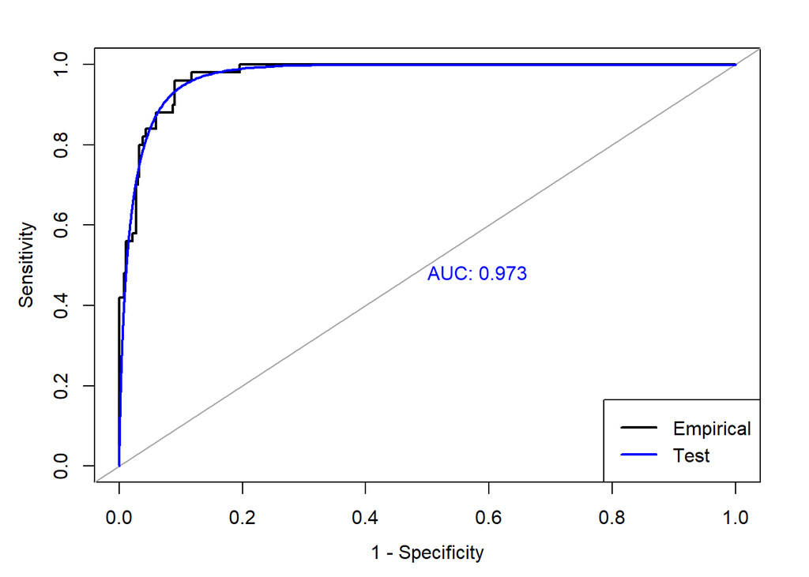

```r
plot.roc(smooth(roc_test), col="blue", add = TRUE,plot=TRUE,print.auc = TRUE, legacy.axes = TRUE, asp =NA)
legend("bottomright", legend=c("Empirical", "Test"),
col=c(par("fg"), "blue"), lwd=2)
```

From the above observations it is clear that Logistic Regression does a great job in doing the requisite classifications. We’ll now look at the performance of the Neural Networks on the same dataset below.

```r
set.seed(777)

control <- trainControl(method = "repeatedcv", number = 10, repeats = 10)

logistic_bayesian <- train(Survived ~ FamilySize+CabinPos+Deck+Pclass+Sex+Age+SibSp+Parch+Fare+Embarked+Title+Mother+Child, data = train, method = "bayesglm", trControl = control, family = binomial(link = "logit"))

acc_bayesian <- paste0(round(max(logistic_bayesian$results$Accuracy),3)*100,'%')
cat('prediction accucary with bayesian logistic regression is ',acc_bayesian,'.\n')
```

```
## prediction accucary with bayesian logistic regression is  82.7% .
```

```r
grid <- expand.grid(size = 1, decay = 0.01)

neuralnet <- train(Survived ~ FamilySize+CabinPos+Deck+Pclass+Sex+Age+SibSp+Parch+Fare+Embarked+Title+Mother+Child, data = train, method = "nnet", trControl = control,maxit = 1000, trace = FALSE, tuneGrid = grid )

acc_nnet <- paste0(round(max(neuralnet$results$Accuracy),3)*100,'%')
cat('prediction accucary of neural net is ',acc_nnet,'.\n')
```

```
## prediction accucary of neural net is  82.9% .
```